# Advanced GIS Study and Research Recommedations

Instructor: Stephen Metts

Fall 2022

### Video Narration:

- The [following video](https://vimeo.com/780509375) is a context narration of the ‘Next Steps’ sections below:

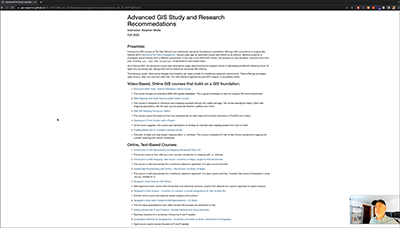

- Password Required: **next_steps_!**

### Preamble:

Introductory GIS courses at The New School have traditionally served as foundational quantitative offerings with connections to programatic themes within the [School for Public Engagement](https://www.newschool.edu/public-engagement/). Several years ago an advanced course was offered as an elective, allowing students to investigate spatial themes from a different perspective. In the case of the NINT5423 course, this perspective was decidedly interactive and front-end, involving `css`, `html` and `javascript` fundamental to web-based maps.

As of Spring 2022, the advanced course was impacted by larger departmental and program trends of decreasing enrollment following Covid-19. Again this upcoming year, Spring 2023 will not feature an advanced GIS offering.

The following ‘guide’ offers some linkages that students can make outside of a traditional classroom environment. These offerings are largely open-source, often low-cost and often free. This offer listing is regional focused (NYC region), or accessible online.

### Video-Based, Online GIS courses that build on a GIS foundation:

1. [Advanced QGIS Topic - Spatial Databases Udemy Course](https://www.udemy.com/share/101YBO3@Ae2UllN4JUVU-R-QhcARa8bURXE2pSoXQXmVINmV3pnEcKRZCXEXV7bpiebGaHSw/)
- The course focuses on extending QGIS with spatial databases. This is good knowledge to have for a typical GIS work environment.
2. [Web-Mapping with Open-Source Leaflet Udemy Course](https://www.udemy.com/share/10241I3@YdoWMqKIuSvuhInAltnY2VO7FtaQ6CvHo4KTw8EqrAA6lHD4wiYML9IoxB2hNlFe/)
- This course is designed to introduce web-mapping concepts through the Leaflet package. The course description reads: *Client side mapping applications with the open source javascript libraries Leaflet.js and Turf.js*
3. [Web GIS Mapping Course on Udemy](https://www.udemy.com/share/103d1E3@r4MM4n5QGMB3PZ1650Byd9rz8PU4afiCVi4nuVryacQPX6mnviDRsSxntBuvA2tvRQ==/)
- This course covers the basics of front-end development for web maps and included discussion of PostGIS and Leaflet.
4. [Openlayers 6 From Scratch with a Project](https://www.udemy.com/share/102dlm3@6D_NNs_xLHUCSlUlsx9F5CMQxevUj8Pd4V3qs0JKEnknkwPFaLuZ6vcLqwHgOxpfYQ==/)
- As the name suggests, this course uses Openlayers to develop an example web mapping project from start to finish.
5. Creating Maps with R - Linkedin Learning Course
- Overview of static and web-based mapping within `R` software. This course is available for free to New School students by logging into Linkedin Learning with school credentials.

### Online, Text-Based Courses:

1. [Introduction to GIS Manipulating and Mapping Geospatial Data in R](https://atlan.com/courses/introduction-to-gis-r/overview/)
- This onine course is free, offering a nice, concise introduction to mapping with `R` software.
2. [Introduction to Web Mapping - Ben-Gurion University of Negev, taught by Michael Dorman](https://geobgu.xyz/web-mapping2/)
- This course is well documented for a traditional classroom approach; it is open-source and free.
3. [Spatial Data Programming with Python - Ben-Gurion University of Negev](https://geobgu.xyz/py/#)
- This course is well documented for a traditional classroom approach; it is open-source and free. Consider this course if interested in using `Python` instead of `R`.
4. [Geographic Data Science with Python](https://geographicdata.science/book/intro.html)
- Well organized online course with introduction and advanced sections coupled with datasets for a python approach to spatial analysis.
5. [Geographic Data Science - University of Liverpool, a course designed by Dr. Dani Arribas-Bel](https://darribas.org/gds_course/content/bD/lab_D.html)
- Another online course that features spatial analysis within python.
6. [Geographic Information Systems (GIS) Specialization - UC Davis](https://www.coursera.org/specializations/gis?irclickid=wne1P-yMaxyNT3XRirxIQRQNUkAxdCxkEWmf200&irgwc=1&utm_medium=partners&utm_source=impact&utm_campaign=3493413&utm_content=b2c#instructors)
- This Coursera specialization track offers several GIS courses and enrollment is free.
7. [Getting started with R and R-spatial - Nicolas Roelandt and Jakub Nowosad](https://bakaniko.github.io/foss4g2022-getting-started-rspatial/)
- Teaching materials for a workshop introducing R and R-spatial.
8. [Quantitative Methods for Geographers - Humboldt-Universität zu Berlin. Department of Geography.](https://pages.cms.hu-berlin.de/EOL/gcg_quantitative-methods/syllabus.html)
- Open-source spatial course focused on R and R-spatial
9. [Analyzing US Census Data: Methods, Maps, and Models in R](https://walker-data.com/census-r/index.html)
- Online version of hardcopy book from the developer of the *tidycensus* R package - arguably the best tool for working with US Census data within a spatial context.
10. [Intro to GIS and Spatial Analysis - ArcGIS Desktop + R - Manuel Gimond](https://mgimond.github.io/Spatial/index.html)
- Good online refresher course for essential spatial analysis in both desktop GIS and R.
11. [Introduction to Python for Geographic Data Analysis - Henrikki Tenkanen, Vuokko Heikinheimo, David Whipp](https://pythongis.org/index.html)
- Introduction to the basics of Python programming and geographic data analysis.

### Guides and Articles:

1. [Open-Source Web-GIS Development Roadmap](https://www.gislounge.com/open-source-web-gis-development-roadmap/)
- This article is a nice overview of different components of web-mapping, and how one might sequence learning them.

### Online applications, portals and utilities:

1. [Google Earth Engine (GEE) - Web-based code editor and datasets API for earth science](https://earthengine.google.com/)
- GEE is an online portal and coding application used to run analysis and queries for very large, global earth science datasets. The coding language is based in javascript where the user/analyst creates scripts in the GEE editor to return specific spatial results in a browser.
2. [Remote Sensing with Google Earth Engine: Fundamentals and Applications - online resource for working with GEE](https://www.eefabook.org/)
- Good introduction to working in GEE.
3. [ARSET - Applied Remote Sensing Training Program](https://appliedsciences.nasa.gov/what-we-do/capacity-building/arset)
- Although not a portal or utility per se, the ARSET program allows for continuing education in earth sciences, and they often have webinar sessions on a variety of spatial analysis and data topics.
4. [Sentinel Hub](https://www.sentinel-hub.com/)
- Sentinel Hub is an engine for processing of petabytes of satellite data. It is opening the doors for machine learning and helping hundreds of application developers worldwide. It makes Sentinel, Landsat, and other Earth observation imagery easily accessible for browsing, visualization and analysis.
5. [Kepler.gl](https://kepler.gl/)
- Kepler.gl is a powerful open source geospatial analysis tool for large-scale data sets. This portal and utility allows for browser-based data manipulation and visualization, designed originally for working with [Uber](https://www.uber.com/) transporation datasets. A blog overview toolbox is located [HERE](https://www.uber.com/blog/keplergl/).
6. [Foursquare Studio (Unfolded Studio)](https://studio.foursquare.com/home)
- Interesting, accessible online studio to develop mapping products and conduct spatial analysis. An introductorty tutorial to using the toolbox is located [HERE](https://youtu.be/72WNCJA55bY).
7. [CARTO](https://carto.com/)
- CARTO is arguably the leading online spatial database portal for web-based mapping. There are two options for getting started with CARTO. First, The New School has an enterprise account which you can join as a student with a New School `.edu` address. The limitation with The New School option is that it features the ‘previous’ user platform - but it is accessible and its free. The second option is a ‘student package’ hosted with Github. To learn more about this option see the documentation [HERE](https://docs.carto.com/faqs/categories/carto-for-education/). This second version features the latest version of the [CARTO Builder](https://carto.com/builder/), whereas The New School account is the previous version so its a bit out-of-date, but again its free and stable.
  - As a student, you can use your `.edu` New School email address to get started [HERE](https://thenewschool.carto.com/signup). The signup requires a username, your `.edu` email address and password:

[figure not shown]

The New School CARTO Enterprise Account Signup

8. [Mapbox Studio](https://www.mapbox.com/mapbox-studio)
- Often used in conjunction with CARTO, Mapbox Studio allows developer tools for basemaps. The application also allows for user data as map layers. Very powerful and intuitive web-based, browser-based application for cartographic design and web-mapping. The free tier allows for ample storage space and access to the core Mapbox Studio tools.
9. [ArcGIS PRO - Student Version](https://www.esri.com/en-us/arcgis/products/arcgis-for-student-use/buy)
- For $100.00 per year, ESRI offers a student version of ArcGIS Pro 3.0 software package. It is the same ArcGIS Pro that ships at full price; what’s different is that the student user license is more restrictive. However, its a great option if you would like to get experience working in another desktop GIS - arguably the most extensive desktop GIS in industry. Make sure to check the [system requirements](https://pro.arcgis.com/en/pro-app/latest/get-started/arcgis-pro-system-requirements.htm) as its a large piece of software and it runs only on PC machines with Windows installed.

### Regional GIS Academic Programs and courses:

1. [New York University - Interactive Web Mapping](https://wagner.nyu.edu//files/syllabi/202201/URPL-GP.4650.001.pdf)
- This course is very similar to The New School’s advanced GIS offering. It is designed to augment desktop GIS with web-based, interactive mapping techniques.
2. [Columbia University Graduate School of Architecture, Planning and Preservation - GSAPP](https://www.arch.columbia.edu/)
- Housed within the Graduate School of Architecture, Planning and Preservation at Columbia, several GIS course offerings are available within this graduate program.
3. [Hunter College CUNY](http://www.geo.hunter.cuny.edu/programs/gis.html)
- Hunter College offers a robust GIS program with multiple course offerings organized around an *advanced certificate*. From the website:

> The GIS Certificate program is a 15-credit post-baccalaureate professional program that offers advanced training in Geographic Information Science (GIS).
4. [Pratt- Spatial Analysis and Design, Advanced Certificate (SAVI)](https://www.pratt.edu/minors/spatial-analysis-and-design-advanced-certificate/)
- Another certificate program, Pratt offers GIS and spatial analysis courses that can lead to a certificate. More information [HERE](https://www.pratt.edu/research/spatial-analysis-visualization-initiative/education/).

### Regional GIS Organizations:

[GISMO NYC](https://www.gismonyc.org/)

- GISMO is New York City’s oldest GIS interest group, comprised of public and private mapping enthusiasts from the tri-state area. If you are looking for a GIS-related job in the region, GISMO is a good organization to join.

[NYS GIS Association](https://www.nysgis.net/)

- As the name suggests, this is New York State’s formal GIS association. Like GISMO, a good organization to join for networking in the GIS field within the state.

### GIS NINT 5380 Fall 2022 - List of Weekly Course Content and Assignments:

**Class 1 | GIS + QGIS orientation:**

- [Course Introduction](https://gis-nspe-tns.github.io//GIS_NINT5380_fall_2022/materials/course.introduction_fall_22_NINT5380.html)
- [Course Syllabus](https://gis-nspe-tns.github.io//GIS_NINT5380_fall_2022/materials/syllabus_fall_22_NINT5380.html)
- [Course Expectations](https://gis-nspe-tns.github.io//GIS_NINT5380_fall_2022/materials/course.expectations_fall_22_NINT5380.html)
- [Class 1 Lecture](https://gis-nspe-tns.github.io/GIS_NINT5380_fall_2022/lectures/lecture.1/index.html)
- [Class 1 Assignment](https://gis-nspe-tns.github.io/GIS_NINT5380_fall_2022/assignments/c1_assignment_fall_22_NINT5380.html)

**Class 2 | Latitude & Longitude:**

- [Class 2 Lecture](https://gis-nspe-tns.github.io/GIS_NINT5380_fall_2022/lectures/lecture.2/index.html#1)
- [Class 2 Assignment](https://gis-nspe-tns.github.io/GIS_NINT5380_fall_2022/assignments/c2_assignment_fall_22_NINT5380.html)
- [Class 2 Lecture Demonstration Lab](https://gis-nspe-tns.github.io/GIS_NINT5380_fall_2022/demos/c2.lecture.demo.html)

**Class 3 | Cartographic Principles & Intro to Symbolization:**

- [Class 3 Lecture](https://gis-nspe-tns.github.io/GIS_NINT5380_fall_2022/lectures/lecture.3/index.html#1)
- [Class 3 Assignment](https://gis-nspe-tns.github.io/GIS_NINT5380_fall_2022/assignments/c3_assignment_fall_22_NINT5380.html)
- [Class 3 Lecture Demonstration Lab](https://gis-nspe-tns.github.io/GIS_NINT5380_fall_2022/demos/c3.lecture.demo.html)

**Class 4 | Thematic Mapping:**

- [Class 4 Lecture](https://gis-nspe-tns.github.io/GIS_NINT5380_fall_2022/lectures/lecture.4/index.html#1)
- [Class 4 Assignment](https://gis-nspe-tns.github.io/GIS_NINT5380_fall_2022/assignments/c4_assignment_fall_22_NINT5380.html)
- [Class 4 Lecture Demonstration Lab](https://gis-nspe-tns.github.io/GIS_NINT5380_fall_2022/demos/c4.lecture.demo.html)

**Class 5 | Introduction to the Raster Data:**

- [Class 5 Lecture](https://gis-nspe-tns.github.io/GIS_NINT5380_fall_2022/lectures/lecture.5/index.html#1)
- [Class 5 Assignment](https://gis-nspe-tns.github.io/GIS_NINT5380_fall_2022/assignments/c5_assignment_fall_22_NINT5380.html)
- [Class 5 Lecture Demonstration Lab](https://gis-nspe-tns.github.io/GIS_NINT5380_fall_2022/demos/c5.lecture.demo.html)

**Class 6 | Map Projections:**

- [Class 6 Lecture](https://gis-nspe-tns.github.io/GIS_NINT5380_fall_2022/lectures/lecture.6/index.html#1)
- [Class 6 Assignment](https://gis-nspe-tns.github.io/GIS_NINT5380_fall_2022/assignments/c6_assignment_fall_22_NINT5380.html)
- [Class 6 Lecture Demonstration Lab](https://gis-nspe-tns.github.io/GIS_NINT5380_fall_2022/demos/c6.lecture.demo.html)

**Class 7 | Geoprocessing:**

- [Class 7 Lecture](https://gis-nspe-tns.github.io/GIS_NINT5380_fall_2022/lectures/lecture.7/index.html#1)
- [Class 7 Assignment](https://gis-nspe-tns.github.io/GIS_NINT5380_fall_2022/assignments/c7_assignment_fall_22_NINT5380.html)
- [Class 7 Lecture Demonstration Lab](https://gis-nspe-tns.github.io/GIS_NINT5380_fall_2022/demos/c7.lecture.demo.html)

**Class 8 | Mapping Vulnerability:**

- [Class 8 Lecture](https://gis-nspe-tns.github.io/GIS_NINT5380_fall_2022/lectures/lecture.8/index.html#1)
- [Class 8 Assignment](https://gis-nspe-tns.github.io/GIS_NINT5380_fall_2022/assignments/c8_assignment_fall_22_NINT5380.html)
- [Class 8 Lecture Demonstration Lab](https://gis-nspe-tns.github.io/GIS_NINT5380_fall_2022/demos/c8.lecture.demo.html)

**Class 9 | Suitability Analysis:**

- [Class 9 Lecture](https://gis-nspe-tns.github.io/GIS_NINT5380_fall_2022/lectures/lecture.9/index.html#1)
- [Class 9 Assignment](https://gis-nspe-tns.github.io/GIS_NINT5380_fall_2022/assignments/c9_assignment_fall_22_NINT5380.html)
- [Class 9 Lecture Demonstration Lab](https://gis-nspe-tns.github.io/GIS_NINT5380_fall_2022/demos/c9.lecture.demo.html)

**Class 10 | Participatory GIS:**

- [Class 10 Lecture](https://gis-nspe-tns.github.io/GIS_NINT5380_fall_2022/lectures/lecture.10/index.html#1)
- [Class 10 Assignment](https://gis-nspe-tns.github.io/GIS_NINT5380_fall_2022/assignments/c10_assignment_fall_22_NINT5380.html)
- [Class 10 Lecture Demonstration Lab](https://gis-nspe-tns.github.io/GIS_NINT5380_fall_2022/demos/c10.lecture.demo.html)

**Class 11 | Remote Sensing & Image Classification:**

- [Class 11 Lecture](https://gis-nspe-tns.github.io/GIS_NINT5380_fall_2022/lectures/lecture.11/index.html#1)
- [Class 11 Assignment](https://gis-nspe-tns.github.io/GIS_NINT5380_fall_2022/assignments/c11_assignment_fall_22_NINT5380.html)
- [Class 11 Lecture Demonstration Lab](https://gis-nspe-tns.github.io/GIS_NINT5380_fall_2022/demos/c11.lecture.demo.html)

**Class 12 | Remote Sensing Indices, density surfaces & interpolation:**

- [Class 12 Lecture](https://gis-nspe-tns.github.io/GIS_NINT5380_fall_2022/lectures/lecture.12/index.html#1)
- [Class 12 Assignment](https://gis-nspe-tns.github.io/GIS_NINT5380_fall_2022/assignments/c12_assignment_fall_22_NINT5380.html)
- [Class 12 Lecture Demonstration Lab](https://gis-nspe-tns.github.io/GIS_NINT5380_fall_2022/demos/c12.lecture.demo.html)